# Naive Bayes algorithm

## Pros:

- It is easy and fast to predict class of test data set. It also perform well in multi class prediction
- When assumption of independence holds, a Naive Bayes classifier performs better compare to other models like logistic regression and you need less training data.
- It perform well in case of categorical input variables compared to numerical variable(s). For numerical variable, normal distribution is assumed (bell curve, which is a strong assumption).

## Cons:

- If categorical variable has a category (in test data set), which was not observed in training data set, then model will assign a 0 (zero) probability and will be unable to make a prediction. This is often known as “Zero Frequency”. To solve this, we can use the smoothing technique. One of the simplest smoothing techniques is called Laplace estimation.
- On the other side naive Bayes is also known as a bad estimator, so the probability outputs from predict_proba are not to be taken too seriously.
- Another limitation of Naive Bayes is the assumption of independent predictors. In real life, it is almost impossible that we get a set of predictors which are completely independent.

## Naive Bayes

- In naive byes therom all the input columns should be categorical columns

```python
### Calling the required library
import pandas as pd
import numpy as np
%matplotlib inline
```

```python
### Importing data set to python
url = 'https://raw.githubusercontent.com/skathirmani/datasets/master/HR%20Analytics.csv'
hr = pd.read_csv(url, sep=',')
hr.head(5)
```

|  | Age | Attrition | BusinessTravel | DailyRate | Department | DistanceFromHome | Education | EducationField | EmployeeCount | EmployeeNumber | ... | RelationshipSatisfaction | StandardHours | StockOptionLevel | TotalWorkingYears | TrainingTimesLastYear | WorkLifeBalance | YearsAtCompany | YearsInCurrentRole | YearsSinceLastPromotion | YearsWithCurrManager |
| --- | --- | --- | --- | --- | --- | --- | --- | --- | --- | --- | --- | --- | --- | --- | --- | --- | --- | --- | --- | --- | --- |
| 0 | 41 | 1 | Travel_Rarely | 1102 | Sales | 1 | 2 | Life Sciences | 1 | 1 | ... | 1 | 80 | 0 | 8 | 0 | 1 | 6 | 4 | 0 | 5 |
| 1 | 49 | 0 | Travel_Frequently | 279 | Research & Development | 8 | 1 | Life Sciences | 1 | 2 | ... | 4 | 80 | 1 | 10 | 3 | 3 | 10 | 7 | 1 | 7 |
| 2 | 37 | 1 | Travel_Rarely | 1373 | Research & Development | 2 | 2 | Other | 1 | 4 | ... | 2 | 80 | 0 | 7 | 3 | 3 | 0 | 0 | 0 | 0 |
| 3 | 33 | 0 | Travel_Frequently | 1392 | Research & Development | 3 | 4 | Life Sciences | 1 | 5 | ... | 3 | 80 | 0 | 8 | 3 | 3 | 8 | 7 | 3 | 0 |
| 4 | 27 | 0 | Travel_Rarely | 591 | Research & Development | 2 | 1 | Medical | 1 | 7 | ... | 4 | 80 | 1 | 6 | 3 | 3 | 2 | 2 | 2 | 2 |

5 rows × 35 columns

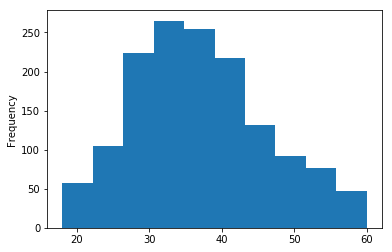

```python
hr['Age'].plot.hist()
```

```python
import numpy as np
bins = [0, 20, 40, 60, 80]
np.digitize([-10], bins=bins)
np.digitize([100], bins=bins)
np.digitize([20], bins=bins)
```

```
array([2], dtype=int64)
```

```python
hr['Age'].quantile((0, 0.25, 0.5, 0.75, 1))
bin_labels = {x: 'B' + str(x) for x in range(6)}
hr['Age_Bin'] = hr['Age_Bin'].replace(bin_labels)
hr[['Age', 'Age_Bin']].head()
```

|  | Age | Age_Bin |
| --- | --- | --- |
| 0 | 41 | B3 |
| 1 | 49 | B3 |
| 2 | 37 | B2 |
| 3 | 33 | B2 |
| 4 | 27 | B2 |

```python
[x*x for x in range(10)]
```

```
[0, 1, 4, 9, 16, 25, 36, 49, 64, 81]
```

```python
{x: 'B' + str(x) for x in range(6)}
```

```
{0: 'B0', 1: 'B1', 2: 'B2', 3: 'B3', 4: 'B4', 5: 'B5'}
```

```python
def numeric2category(numeric_series):
    bins = numeric_series.quantile((0, 0.25, 0.5, 0.75, 1)).values
    bin_labels = {x: 'B' + str(x) for x in range(len(bins)+1)}
    categories_array = np.digitize(numeric_series, bins=bins)
    category_series = pd.Series(categories_array)
    return (category_series.replace(bin_labels))
numeric2category(hr['Age']).head()
```

```
0    B3
1    B4
2    B3
3    B2
4    B1
dtype: object
```

### Converting all to numeric columns to category columns

```python
num_cols = hr._get_numeric_data().columns.drop('Attrition')
df_categories = pd.DataFrame(columns=num_cols)
for col in num_cols:
    df_categories[col] = numeric2category(hr[col])
df_categories.head()
```

|  | Age | DailyRate | DistanceFromHome | Education | EmployeeCount | EmployeeNumber | EnvironmentSatisfaction | HourlyRate | JobInvolvement | JobLevel | ... | StandardHours | StockOptionLevel | TotalWorkingYears | TrainingTimesLastYear | WorkLifeBalance | YearsAtCompany | YearsInCurrentRole | YearsSinceLastPromotion | YearsWithCurrManager | Age_bin |
| --- | --- | --- | --- | --- | --- | --- | --- | --- | --- | --- | --- | --- | --- | --- | --- | --- | --- | --- | --- | --- | --- |
| 0 | B3 | B3 | B1 | B2 | B5 | B1 | B2 | B4 | B4 | B3 | ... | B5 | B2 | B2 | B1 | B1 | B3 | B3 | B2 | B3 | B4 |
| 1 | B4 | B1 | B3 | B1 | B5 | B1 | B3 | B2 | B2 | B3 | ... | B5 | B4 | B3 | B4 | B4 | B4 | B4 | B3 | B4 | B4 |
| 2 | B3 | B4 | B2 | B2 | B5 | B1 | B5 | B4 | B2 | B2 | ... | B5 | B2 | B2 | B4 | B4 | B1 | B1 | B2 | B1 | B3 |
| 3 | B2 | B4 | B2 | B4 | B5 | B1 | B5 | B2 | B4 | B2 | ... | B5 | B2 | B2 | B4 | B4 | B3 | B4 | B4 | B1 | B3 |
| 4 | B1 | B2 | B2 | B1 | B5 | B1 | B1 | B1 | B4 | B2 | ... | B5 | B4 | B2 | B4 | B4 | B1 | B2 | B3 | B2 | B3 |

5 rows × 27 columns

### Attaching the category columns to the data frame

```python
cat_cols = hr.columns.drop(num_cols)
df_final = pd.concat([df_categories, hr[cat_cols]], axis=1)
df_final.head()
```

|  | Age | DailyRate | DistanceFromHome | Education | EmployeeCount | EmployeeNumber | EnvironmentSatisfaction | HourlyRate | JobInvolvement | JobLevel | ... | Attrition | BusinessTravel | Department | EducationField | Gender | JobRole | MaritalStatus | Over18 | OverTime | Age_Bin |
| --- | --- | --- | --- | --- | --- | --- | --- | --- | --- | --- | --- | --- | --- | --- | --- | --- | --- | --- | --- | --- | --- |
| 0 | B3 | B3 | B1 | B2 | B5 | B1 | B2 | B4 | B4 | B3 | ... | 1 | Travel_Rarely | Sales | Life Sciences | Female | Sales Executive | Single | Y | Yes | B3 |
| 1 | B4 | B1 | B3 | B1 | B5 | B1 | B3 | B2 | B2 | B3 | ... | 0 | Travel_Frequently | Research & Development | Life Sciences | Male | Research Scientist | Married | Y | No | B3 |
| 2 | B3 | B4 | B2 | B2 | B5 | B1 | B5 | B4 | B2 | B2 | ... | 1 | Travel_Rarely | Research & Development | Other | Male | Laboratory Technician | Single | Y | Yes | B2 |
| 3 | B2 | B4 | B2 | B4 | B5 | B1 | B5 | B2 | B4 | B2 | ... | 0 | Travel_Frequently | Research & Development | Life Sciences | Female | Research Scientist | Married | Y | Yes | B2 |
| 4 | B1 | B2 | B2 | B1 | B5 | B1 | B1 | B1 | B4 | B2 | ... | 0 | Travel_Rarely | Research & Development | Medical | Male | Laboratory Technician | Married | Y | No | B2 |

5 rows × 37 columns

### Spliting data into train and test data

```python
from sklearn.model_selection import train_test_split
train, test = train_test_split(df_final, test_size=0.3, random_state=100)
print(train.shape)
print(test.shape)
train.head()
```

```
(1029, 37)
(441, 37)
```

|  | Age | DailyRate | DistanceFromHome | Education | EmployeeCount | EmployeeNumber | EnvironmentSatisfaction | HourlyRate | JobInvolvement | JobLevel | ... | Attrition | BusinessTravel | Department | EducationField | Gender | JobRole | MaritalStatus | Over18 | OverTime | Age_Bin |
| --- | --- | --- | --- | --- | --- | --- | --- | --- | --- | --- | --- | --- | --- | --- | --- | --- | --- | --- | --- | --- | --- |
| 178 | B4 | B2 | B1 | B2 | B5 | B1 | B2 | B4 | B4 | B4 | ... | 0 | Travel_Rarely | Sales | Marketing | Female | Sales Executive | Divorced | Y | No | B3 |
| 971 | B4 | B4 | B3 | B2 | B5 | B3 | B5 | B3 | B2 | B4 | ... | 0 | Travel_Rarely | Research & Development | Technical Degree | Female | Manufacturing Director | Single | Y | No | B3 |
| 1172 | B1 | B2 | B3 | B3 | B5 | B4 | B3 | B1 | B2 | B3 | ... | 0 | Travel_Rarely | Sales | Medical | Male | Sales Executive | Single | Y | No | B2 |
| 667 | B3 | B3 | B2 | B4 | B5 | B2 | B2 | B2 | B1 | B2 | ... | 1 | Travel_Rarely | Research & Development | Life Sciences | Female | Laboratory Technician | Divorced | Y | Yes | B3 |
| 399 | B2 | B1 | B1 | B2 | B5 | B2 | B5 | B4 | B2 | B2 | ... | 0 | Travel_Rarely | Research & Development | Life Sciences | Male | Laboratory Technician | Married | Y | No | B2 |

5 rows × 37 columns

```python
pd.pivot_table(data=train,
               index='Attrition',
               columns='Gender',
               values='MaritalStatus',
               aggfunc=np.count_nonzero)
```

| Gender Attrition | Female | Male |
| --- | --- | --- |
| 0 | 357 | 505 |
| 1 | 62 | 105 |

```python
pd.pivot_table(data=train,
               index='Attrition',
               columns='MaritalStatus',
               values='Gender',
               aggfunc=np.count_nonzero)
```

| MaritalStatus Attrition | Divorced | Married | Single |
| --- | --- | --- | --- |
| 0 | 210 | 408 | 244 |
| 1 | 25 | 57 | 85 |

### Prediction Using Naive Bayes Algorithm

```python
from sklearn.naive_bayes import GaussianNB
df_model = pd.get_dummies(df_final)
train, test = train_test_split(df_model, test_size=0.3, random_state=100)

train_y = train['Attrition']
test_y = test['Attrition']

train_x = train.drop('Attrition', axis=1)
test_x = test.drop('Attrition', axis=1)

model = GaussianNB()
model.fit(train_x, train_y)
test_pred = model.predict(test_x)
df_pred = pd.DataFrame({'Actual': test_y,
                       'Predicted': test_pred})
df_pred['pred_status']=df_pred['Actual']==df_pred['Predicted']
df_pred['pred_status'].sum()/df_pred.shape[0]*100
```

```
45.3514739229025
```